# mh

## Mental Health study in Tech industry

This research explores **mental health trends in the tech industry** using Open Source Mental Illness (OSMI) survey data from **2014 to 2019**. The analysis focuses on employer size, workplace awareness initiatives, and the prevalence of diagnosed mental health conditions among employees.

The dataset relies on **self-reported responses**, which may introduce biases, such as **overrepresentation of certain demographics** or **self-selection bias** among respondents.

```python
import pandas as pd
import matplotlib.pyplot as plt
import sqlite3 as sql
import numpy as np
%matplotlib inline

path = "mental_health.sqlite"
con = sql.connect(path)
```

First of all, we attempt to get a better understanding of how the data was collected, and for this we need to take a look at the questionairre for each year of the survey.

```python
query = """
    SELECT
        a.QuestionID,
        q.QuestionText AS questiontext,
        a.SurveyID AS Year,
        COUNT(DISTINCT a.UserID) AS respondents
    FROM Answer a
    JOIN Question q ON a.QuestionID = q.QuestionID
    GROUP BY a.QuestionID, q.QuestionText, a.SurveyID
    ORDER BY a.QuestionID, a.SurveyID;
"""

questionnaire = pd.read_sql(query, con)
pivot_table = questionnaire.pivot_table(
    index='QuestionID',
    columns='Year',
    values='respondents',
    aggfunc='sum'
).fillna(0).astype(int)

result = pivot_table.merge(
    questionnaire[['QuestionID', 'questiontext']].drop_duplicates(),
    on='QuestionID',
    how='left'
)

result.set_index('QuestionID', inplace=True)
print('Which questions were asked which year?')
print(result.to_string())
```

```
Which questions were asked which year?
            2014  2016  2017  2018  2019                                                                                                                                                                                                                      questiontext
QuestionID
1           1260  1433   756   417   352                                                                                                                                                                                                                 What is your age?
2           1260  1433   756   417   352                                                                                                                                                                                                              What is your gender?
3           1260  1433   756   417   352                                                                                                                                                                                                      What country do you live in?
4           1260  1433   756   417   352                                                                                                                                                        If you live in the United States, which state or territory do you live in?
5           1260  1433   756   417   352                                                                                                                                                                                                            Are you self-employed?
6           1260  1433   756   417   352                                                                                                                                                                                   Do you have a family history of mental illness?
7           1260  1433   756   417   352                                                                                                                                    Have you ever sought treatment for a mental health disorder from a mental health professional?
8           1260  1433   756   417   352                                                                                                                                                                        How many employees does your company or organization have?
9           1260  1433   756   417   352                                                                                                                                                                           Is your employer primarily a tech company/organization?
10          1260  1433   756   417   352                                                                                                                                                 Does your employer provide mental health benefits as part of healthcare coverage?
11          1260  1433   756   417   352                                                                                    Is your anonymity protected if you choose to take advantage of mental health or substance abuse treatment resources provided by your employer?
12          1260  1433   756   417   352                                                                                                                                               Would you bring up a mental health issue with a potential employer in an interview?
```

[output cut: 93 more lines]

# Observations from first look at the survey

- No data at all for 2015.
- Question index 35-47 are missing in the dataset.
- Questions 1-12 were asked in all 5 surveys (2014-2019).
- Questions 1-35, 47-56 were asked in 4 consecutive surveys (2016-2019).
- Questions 1-35, 47-89 were asked in 3 consecutive surveys (2017-2019).
- Questions 90-118 were asked in 2014 or 2016. These are similar to the questions asked in later surveys, but wording a question differently does not provide a good unbiased way for comparison.
- Questions 115-116 offer insight into specific ilness, but was only asked in 2016.

Next, let's have a look at our population of respondents.

```python
query = """
SELECT AnswerText, COUNT(DISTINCT UserID) as Responses
FROM Answer
WHERE QuestionID = 3
GROUP BY AnswerText
ORDER BY Responses DESC;
"""
run_sql = pd.read_sql(query, con)
print('How many responses from each country?')
total_responses = run_sql['Responses'].sum()
print(f"Total sum of responses: {total_responses}")
print("* Need to correct for United States appearing twice")
run_sql
```

```
How many responses from each country?
Total sum of responses: 4218
* Need to correct for United States appearing twice
```

|  | AnswerText | Responses |
| --- | --- | --- |
| 0 | United States of America | 1853 |
| 1 | United States | 751 |
| 2 | United Kingdom | 482 |
| 3 | Canada | 199 |
| 4 | Germany | 136 |
| ... | ... | ... |
| 76 | Ethiopia | 1 |
| 77 | Ecuador | 1 |
| 78 | Brunei | 1 |
| 79 | Belarus | 1 |
| 80 | Bahamas, The | 1 |

81 rows × 2 columns

```python
query = """
SELECT * FROM Answer
ORDER BY UserID, SurveyID;
"""
df = pd.read_sql(query, con)
con.close()
df = df.drop_duplicates(subset=['UserID', 'SurveyID', 'QuestionID'])
df = df.pivot(index=['UserID', 'SurveyID'], columns='QuestionID', values='AnswerText').reset_index()
df = df[['UserID', 'SurveyID', 1, 2, 3, 7, 8, 9, 16, 17, 34, 115, 117]]
df.columns = ['UserID', 'SurveyID', 'Age', 'Gender', 'Country', 'Sought_Treatment', 'Employer_Size',
              'Employer_Tech', 'Employer_Initiative', 'Offer_Resources', 'MH_Diagnosed', 'MH_Conditions',
              'Position']

df['Gender'] = df['Gender'].str.strip().str.capitalize()
df['Gender'] = df['Gender'].where(df['Gender'].isin(['Male', 'Female']))
df['Age'] = pd.to_numeric(df['Age'], errors='coerce')
df['Country'] = df['Country'].str.strip().replace('United States', 'United States of America')
df = df[(df['Age'] >= 18) & (df['Age'] <= 64)]
df = df.set_index('UserID')
df
```

| UserID | SurveyID | Age | Gender | Country | Sought_Treatment | Employer_Size | Employer_Tech | Employer_Initiative | Offer_Resources | MH_Diagnosed | MH_Conditions | Position |
| --- | --- | --- | --- | --- | --- | --- | --- | --- | --- | --- | --- | --- |
| 1 | 2014 | 37 | Female | United States of America | 1 | 6-25 | 1 | NaN | NaN | NaN | NaN | NaN |
| 2 | 2014 | 44 | Male | United States of America | 0 | More than 1000 | 0 | NaN | NaN | NaN | NaN | NaN |
| 3 | 2014 | 32 | Male | Canada | 0 | 6-25 | 1 | NaN | NaN | NaN | NaN | NaN |
| 4 | 2014 | 31 | Male | United Kingdom | 1 | 26-100 | 1 | NaN | NaN | NaN | NaN | NaN |
| 5 | 2014 | 31 | Male | United States of America | 0 | 100-500 | 1 | NaN | NaN | NaN | NaN | NaN |
| ... | ... | ... | ... | ... | ... | ... | ... | ... | ... | ... | ... | ... |
| 4214 | 2019 | 27 | Male | India | 0 | More than 1000 | 0 | I don't know | Somewhat difficult | -1 | NaN | NaN |
| 4215 | 2019 | 48 | Male | United States of America | 0 | -1 | -1 | -1 | -1 | -1 | NaN | NaN |
| 4216 | 2019 | 50 | Male | India | 0 | -1 | -1 | -1 | -1 | -1 | NaN | NaN |
| 4217 | 2019 | 30 | Female | India | 0 | More than 1000 | 1 | No | Difficult | -1 | NaN | NaN |
| 4218 | 2019 | 24 | Female | United States of America | 1 | More than 1000 | 1 | Yes | Somewhat difficult | Yes | NaN | NaN |

4192 rows × 12 columns

## Key Columns for Analysis

Let's check if our variables have any correlation.

```python
df_numeric = df.apply(pd.to_numeric, errors="coerce").corr()
df_numeric.corr()
```

|  | SurveyID | Age | Gender | Country | Sought_Treatment | Employer_Size | Employer_Tech | Employer_Initiative | Offer_Resources | MH_Diagnosed | MH_Conditions | Position |
| --- | --- | --- | --- | --- | --- | --- | --- | --- | --- | --- | --- | --- |
| SurveyID | 1.000000 | 0.078874 | NaN | NaN | -0.140144 | NaN | -0.634731 | NaN | NaN | NaN | NaN | NaN |
| Age | 0.078874 | 1.000000 | NaN | NaN | -0.190038 | NaN | -0.605816 | NaN | NaN | NaN | NaN | NaN |
| Gender | NaN | NaN | NaN | NaN | NaN | NaN | NaN | NaN | NaN | NaN | NaN | NaN |
| Country | NaN | NaN | NaN | NaN | NaN | NaN | NaN | NaN | NaN | NaN | NaN | NaN |
| Sought_Treatment | -0.140144 | -0.190038 | NaN | NaN | 1.000000 | NaN | -0.331980 | NaN | NaN | NaN | NaN | NaN |
| Employer_Size | NaN | NaN | NaN | NaN | NaN | NaN | NaN | NaN | NaN | NaN | NaN | NaN |
| Employer_Tech | -0.634731 | -0.605816 | NaN | NaN | -0.331980 | NaN | 1.000000 | NaN | NaN | NaN | NaN | NaN |
| Employer_Initiative | NaN | NaN | NaN | NaN | NaN | NaN | NaN | NaN | NaN | NaN | NaN | NaN |
| Offer_Resources | NaN | NaN | NaN | NaN | NaN | NaN | NaN | NaN | NaN | NaN | NaN | NaN |
| MH_Diagnosed | NaN | NaN | NaN | NaN | NaN | NaN | NaN | NaN | NaN | NaN | NaN | NaN |
| MH_Conditions | NaN | NaN | NaN | NaN | NaN | NaN | NaN | NaN | NaN | NaN | NaN | NaN |
| Position | NaN | NaN | NaN | NaN | NaN | NaN | NaN | NaN | NaN | NaN | NaN | NaN |

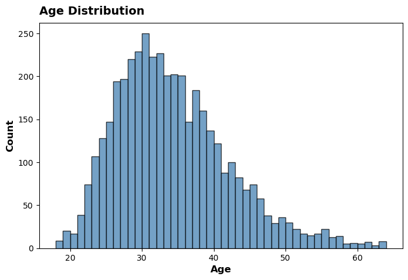

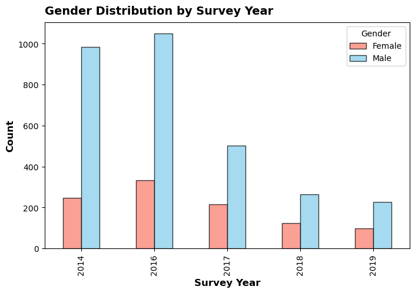

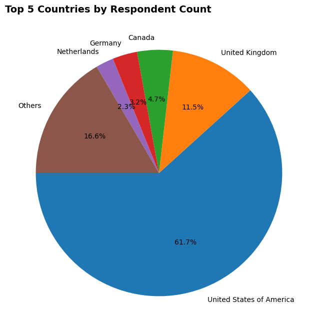

```python
# Age Distribution - Histogram
fig, ax = plt.subplots(figsize=(8, 5))
ax.hist(df["Age"], bins=46, edgecolor="black", alpha=0.75, color="steelblue")

ax.set_title("Age Distribution", fontsize=14, fontweight="bold", loc="left", pad=10)
ax.set_xlabel("Age", fontsize=12, fontweight="bold")
ax.set_ylabel("Count", fontsize=12, fontweight="bold")

ax.set_facecolor("white")
ax.tick_params(axis="both", which="major", labelsize=10)

plt.show()

# Gender Distribution - Bar Chart
fig, ax = plt.subplots(figsize=(8, 5))
df.groupby(["SurveyID", "Gender"]).size().unstack().plot(
    kind="bar", ax=ax, color=["salmon", "skyblue"], edgecolor="black", alpha=0.75
)

ax.set_title("Gender Distribution by Survey Year", fontsize=14, fontweight="bold", loc="left", pad=10)
ax.set_xlabel("Survey Year", fontsize=12, fontweight="bold")
ax.set_ylabel("Count", fontsize=12, fontweight="bold")

ax.set_facecolor("white")
ax.tick_params(axis="both", which="major", labelsize=10)
ax.legend(title="Gender")

plt.show()

# Country Distribution - Pie Chart
country_counts = df["Country"].value_counts()
top = country_counts[:5]
others = country_counts[5:].sum()
top["Others"] = others

plt.figure(figsize=(8, 8))
plt.pie(top, labels=top.index, autopct="%1.1f%%", startangle=180)
plt.title("Top 5 Countries by Respondent Count", fontsize=14, fontweight="bold", loc="left", pad=10)

plt.show()
```

## Data Bias and Representation Analysis

- ✅ Right-leaning, normally distributed age of respondents centered around 30.
- ✅ 70%+ male representation.
- ✅ Over 60% of respondents are from the United States.

### Potential Bias Concerns

- ⚠️ Possible bias towards:
  - A tech worker.
  - Working in the United States.
  - In a tech company.
  - With increased likelihood of perceived or diagnosed mental health issues.
- ⚠️ Gender disparity may be amplified due to the overrepresentation of the tech industry.
- ⚠️ Known biases in the tech field may influence our observations.

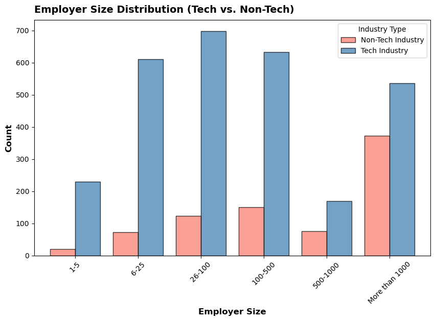

```python
df["Employer_Tech"] = df["Employer_Tech"].replace("-1", pd.NA)
df["Employer_Size"] = df["Employer_Size"].replace("-1", pd.NA).fillna("Unknown")
df["Employer_Tech"] = pd.to_numeric(df["Employer_Tech"], errors="coerce")

df_grouped = df.groupby(["Employer_Size", "Employer_Tech"]).size().unstack()
bucket_order = ["1-5", "6-25", "26-100", "100-500", "500-1000", "More than 1000"]
df_grouped = df_grouped.reindex(bucket_order)

fig, ax = plt.subplots(figsize=(10, 6))
df_grouped.plot(kind="bar", ax=ax, color=["salmon", "steelblue"], edgecolor="black", alpha=0.75, width=0.8)

ax.set_title("Employer Size Distribution (Tech vs. Non-Tech)", fontsize=14, fontweight="bold", loc="left", pad=10)
ax.set_xlabel("Employer Size", fontsize=12, fontweight="bold")
ax.set_ylabel("Count", fontsize=12, fontweight="bold")
ax.set_xticklabels(ax.get_xticklabels(), rotation=45)
ax.legend(["Non-Tech Industry", "Tech Industry"], title="Industry Type")

plt.show()
```

## Company Size and Industry Distribution

### Potential Implications

- ⚖️ Larger Non-Tech companies may have a higher proportion of IT roles compared to smaller Non-Tech companies in the US.
- 📢 The survey may have been more accessible to Tech employees in **larger Non-Tech companies** in the US than to those in smaller firms.

The **2016 survey** asked respondents to select the position that best described their role at the time of taking the survey. This allows us to analyze potential relationships between **mental health** and job position. Additionally, **2016** was the only year in which the survey asked respondents to specify a mental health condition if they had one or more.

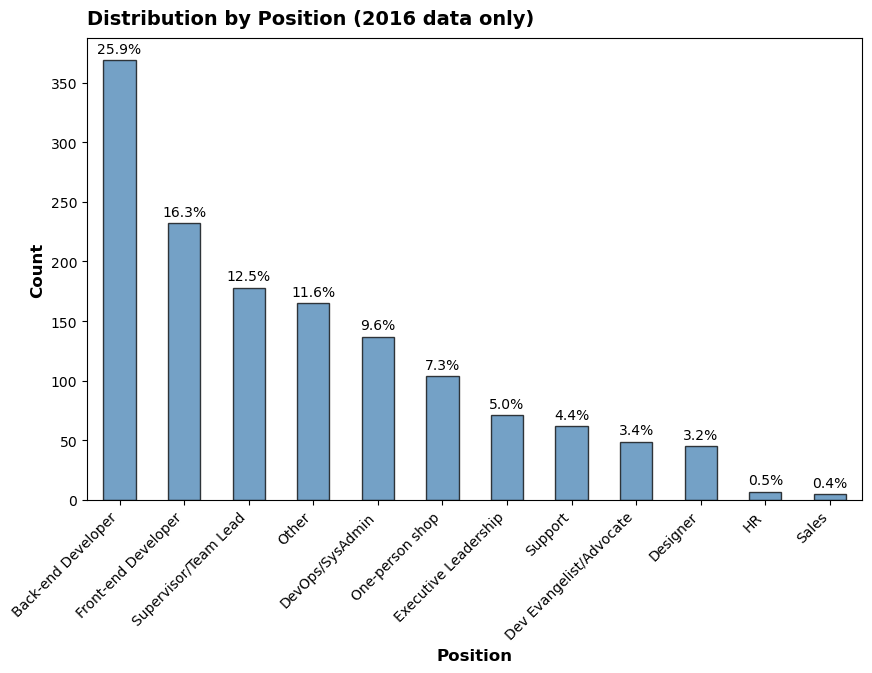

```python
df_2016 = df[df["SurveyID"] == 2016]
position_counts = df_2016["Position"].value_counts(dropna=False)
position_percentages = position_counts / position_counts.sum() * 100

fig, ax = plt.subplots(figsize=(10, 6))
bars = position_counts.plot(kind="bar", ax=ax, color="steelblue", edgecolor="black", alpha=0.75)

ax.bar_label(bars.containers[0], labels=[f"{v:.1f}%" for v in position_percentages], fontsize=10, padding=3)
ax.set_title("Distribution by Position (2016 data only)", fontsize=14, fontweight="bold", loc="left", pad=10)
ax.set_xlabel("Position", fontsize=12, fontweight="bold")
ax.set_ylabel("Count", fontsize=12, fontweight="bold")
ax.tick_params(axis="both", which="major", labelsize=10)
ax.set_xticklabels(ax.get_xticklabels(), rotation=45, ha="right")
ax.set_facecolor("white")

plt.show()
```

# Prevalence rate for 3 mental health diseases

```python
df["MH_Conditions"] = df["MH_Conditions"].replace("-1", "Other")
print("List values and count in Mental Health condition column, where indicated\n")
print(df["MH_Conditions"].value_counts(dropna=False).to_string(index=True, header=False))
```

```
List values and count in Mental Health condition column, where indicated

NaN                                                                                                                                                          2768
Other                                                                                                                                                         860
Anxiety Disorder (Generalized, Social, Phobia, etc)                                                                                                           333
Mood Disorder (Depression, Bipolar Disorder, etc)                                                                                                             162
Attention Deficit Hyperactivity Disorder                                                                                                                       25
Post-traumatic Stress Disorder                                                                                                                                  9
Psychotic Disorder (Schizophrenia, Schizoaffective, etc)                                                                                                        6
Personality Disorder (Borderline, Antisocial, Paranoid, etc)                                                                                                    5
Obsessive-Compulsive Disorder                                                                                                                                   5
Stress Response Syndromes                                                                                                                                       3
Substance Use Disorder                                                                                                                                          2
Eating Disorder (Anorexia, Bulimia, etc)                                                                                                                        2
I haven't been formally diagnosed, so I felt uncomfortable answering, but Social Anxiety and Depression.                                                        1
Combination of physical impairment (strongly near-sighted) with a possibly mental one (MCD / "ADHD", though its actually a stimulus filtering impairment)       1
Sexual addiction                                                                                                                                                1
Autism Spectrum Disorder                                                                                                                                        1
Transgender                                                                                                                                                     1
Addictive Disorder                                                                                                                                              1
Autism (Asperger's)                                                                                                                                             1
Depression                                                                                                                                                      1
PDD-NOS                                                                                                                                                         1
Burn out                                                                                                                                                        1
Seasonal Affective Disorder                                                                                                                                     1
Schizotypal Personality Disorder                                                                                                                                1
```

## Focus Areas of Analysis

We will examine the presence of mental health conditions among respondents in specific roles, focusing on:

- 🧠 **Anxiety**
- 🌧️ **Mood Disorder**
- ⚡ **ADHD**

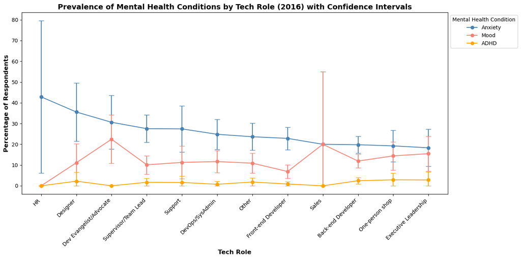

```python
df_2016 = df[df["SurveyID"] == 2016].copy()

conditions = {
    "Anxiety Disorder (Generalized, Social, Phobia, etc)": "Anxiety",
    "Mood Disorder (Depression, Bipolar Disorder, etc)": "Mood",
    "Attention Deficit Hyperactivity Disorder": "ADHD"
}

df_2016["MH_Conditions"] = df_2016["MH_Conditions"].astype(str)

for condition, short_name in conditions.items():
    df_2016[short_name] = df_2016["MH_Conditions"].str.contains(condition, regex=False, case=False)

role_counts = df_2016["Position"].value_counts()
mh_percentages, mh_ci_lower, mh_ci_upper = {}, {}, {}

for short_name in conditions.values():
    mh_role_counts = df_2016[df_2016[short_name]]["Position"].value_counts()
    proportion = mh_role_counts / role_counts
    mh_percentages[short_name] = (proportion * 100).fillna(0)

    standard_error = np.sqrt((proportion * (1 - proportion)) / role_counts)
    ci_margin = 1.96 * standard_error

    mh_ci_lower[short_name] = ((proportion - ci_margin) * 100).clip(lower=0).fillna(0)
    mh_ci_upper[short_name] = ((proportion + ci_margin) * 100).fillna(0)

mh_role_df = pd.DataFrame(mh_percentages).sort_values(by=list(conditions.values()), ascending=False)
mh_ci_lower_df = pd.DataFrame(mh_ci_lower).reindex(mh_role_df.index)
mh_ci_upper_df = pd.DataFrame(mh_ci_upper).reindex(mh_role_df.index)

fig, ax = plt.subplots(figsize=(14, 7))
colors = {"Anxiety": "#4682B4", "Mood": "#FA8072", "ADHD": "#FFA500"}

for condition in conditions.values():
    ax.plot(mh_role_df.index, mh_role_df[condition], marker='o', linestyle='-', label=condition, color=colors[condition])
    ax.errorbar(
        mh_role_df.index, mh_role_df[condition],
        yerr=[mh_role_df[condition] - mh_ci_lower_df[condition], mh_ci_upper_df[condition] - mh_role_df[condition]],
        fmt='o', color=colors[condition], capsize=5, capthick=1, linestyle=''
    )

ax.set_title("Prevalence of Mental Health Conditions by Tech Role (2016) with Confidence Intervals", fontsize=14, fontweight="bold")
ax.set_xlabel("Tech Role", fontsize=12, fontweight="bold")
ax.set_ylabel("Percentage of Respondents", fontsize=12, fontweight="bold")

ax.set_xticks(range(len(mh_role_df.index)))
ax.set_xticklabels(mh_role_df.index, rotation=45, ha="right")

ax.legend(title="Mental Health Condition", loc="upper left", bbox_to_anchor=(1, 1))

plt.tight_layout()
plt.show()
```

## Role-Based Mental Health Analysis

The diagram above illustrates how different roles within the industry may impact respondents' mental health status. Certain roles show higher diagnosis rates for mental health conditions than others.

The dots represent the estimated mean value for each role/condition, while the confidence intervals indicate the range within which the true ratio is expected to fall with 95% confidence, accounting for sampling error. Note that not all confidence intervals are meaningful due to small sample size.

```
MH_Diagnosed     No  Yes
Employer_Size
1-5              33   38
6-25            116  163
26-100          149  229
100-500         124  287
500-1000         45   86
More than 1000  121  320
```

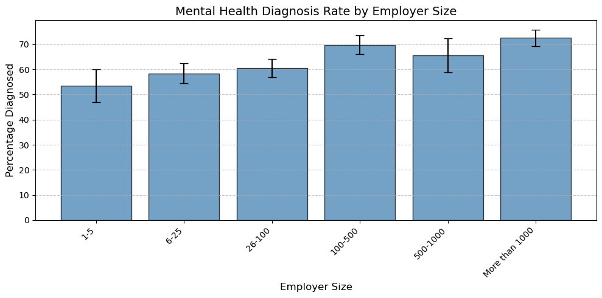

```python
df = df[df["Employer_Size"] != "-1"]
df = df[df["MH_Diagnosed"] != "-1"]

df["Employer_Size"] = pd.Categorical(df["Employer_Size"], categories=bucket_order, ordered=True)
print(pd.crosstab(df["Employer_Size"], df["MH_Diagnosed"]))
df["MH_Diagnosed"] = df["MH_Diagnosed"].map({"Yes": 1, "No": 0}).dropna()

mh_rates = df.groupby("Employer_Size", observed=True)["MH_Diagnosed"].mean() * 100
n_counts = df["Employer_Size"].value_counts()
se = np.sqrt((mh_rates / 100) * (1 - mh_rates / 100) / n_counts) * 100
ci_margin = 1.96 * se

fig, ax = plt.subplots(figsize=(10, 5))
ax.bar(mh_rates.index, mh_rates.values, yerr=ci_margin, capsize=5, color="steelblue", edgecolor="black", alpha=0.75)
ax.set_title("Mental Health Diagnosis Rate by Employer Size", fontsize=14)
ax.set_xlabel("Employer Size", fontsize=12)
ax.set_ylabel("Percentage Diagnosed", fontsize=12)
ax.set_xticks(range(len(mh_rates.index)))
ax.set_xticklabels(mh_rates.index, rotation=45, ha="right")

plt.grid(axis="y", linestyle="--", alpha=0.7)
plt.tight_layout()
plt.show()
```

## Employer Size and Mental Health Diagnosis

Looking at the diagram above, it may appear that the **larger the employer**, the higher the likelihood that respondents have at least one diagnosed mental health condition.

### Key Question

Does this trend indicate that:

- 🔍 **A)** Larger employers expose employees to more stress factors, increasing the risk of mental health conditions?
- 🌱 **B)** Larger employers have a stronger focus on raising awareness and encouraging mental health diagnoses among employees?

Let's take a closer look. 👀

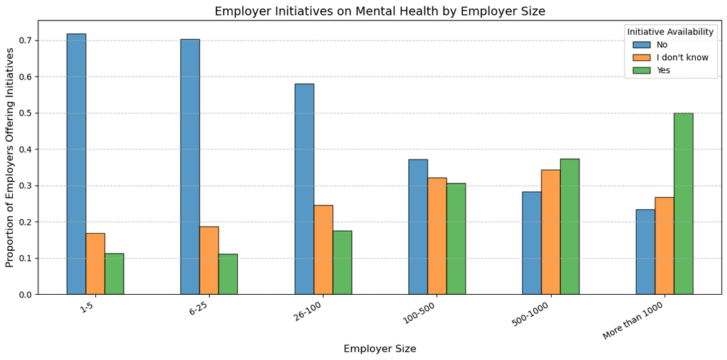

```python
df = df[df["Employer_Initiative"].notna()]
initiative_rates = df.groupby("Employer_Size", observed=True)["Employer_Initiative"].value_counts(normalize=True).unstack()

fig, ax = plt.subplots(figsize=(12, 6))
initiative_rates.plot(kind="bar", ax=ax, alpha=0.75, edgecolor="black")
ax.set_title("Employer Initiatives on Mental Health by Employer Size", fontsize=14)
ax.set_xlabel("Employer Size", fontsize=12)
ax.set_ylabel("Proportion of Employers Offering Initiatives", fontsize=12)
ax.legend(title="Initiative Availability")
ax.set_xticklabels(initiative_rates.index, rotation=30, ha="right")

plt.grid(axis="y", linestyle="--", alpha=0.7)
plt.tight_layout()
plt.show()
```

## Summary & Final Thoughts

It appears that the **larger the employer**, the more likely it is that they invest extra effort in raising awareness about mental health.

However, a lower proportion of *"I don't know"* responses among employees of smaller companies suggests that respondents from **larger organizations** may find it harder to access mental health-related information. This could be due to **information clutter** and **bureaucracy** within large companies, but we will leave this for another research.

Understanding mental health in tech workplaces requires ongoing research, as both awareness and stigma evolve over time.